# P6_Chadeau_notebook2_analyse_ca

```python
from IPython.core.display import display, HTML
f = open("P6_Chadeau_notebook2_sommaire.html", "r", encoding="utf-8")
display(HTML(f.read()))
```

TOP  
Importation des librairies et fichiers  
Déclaration des fonctions  
Importation dataframe  
La mission

- Analyse du chiffre d'affaires

- Evolution du CA entre mars 2021 et février 2023

- Comparaison du CA sur les 2 périodes de 12 mois

- Tendance CA - Décomposition CA en moyenne mobile

- Evolution du CA entre mars 2021 et février 2023 (boxplot)

Suite du projet : Analyses univariées

# Projet 6 -Analysez les ventes d'une librairie avec R ou Python

[figure not shown]

## NOTEBOOK 2 - ANALYSE DU CHIFFRE D'AFFAIRES

### Importation des librairies et fichiers

```python
import pandas as pd
import numpy as np
import re
import matplotlib.pyplot as plt
import seaborn as sns
import datetime
from statsmodels.tsa.stattools import adfuller
from simple_colors import *

#Permet d'afficher toutes les lignes d'une liste
pd.set_option("max_rows", None)

#Permet l'affichage de tous les résultats d'une cellule (pas seulement le dernier)
from IPython.core.interactiveshell import InteractiveShell
InteractiveShell.ast_node_interactivity = "all"

#Permet de définir des paramètres d'affichage pour l'ensemble des graphiques
from pylab import rcParams
rcParams['figure.figsize'] = 15, 5
```

### Déclaration des fonctions

```python
class graphic():
    def lorenz_gini(data,title,medial,mediane):

        n = len(data)
        #Tri des individus dans l'ordre croissant des valeurs de la variable + calcul de la somme cumulée
        #et division par la somme des observations afin que le haut de la courbe soit à 1
        lorenz = np.cumsum(np.sort(data)) / data.sum()
        lorenz = np.append([0],lorenz)

        fig = plt.figure(figsize=(6, 6))
        memo=plt.axes().axis('equal')
        xaxis=np.linspace(0,1,len(lorenz))

        plt.plot(xaxis,lorenz,'blue', label='M')
        memo=plt.axis([0, 1, 0, 1])

        memo=plt.plot([0, 1], [0, 1], 'r-', lw=2, label='Première bissectrice (distribution égalitaire)')
        memo=plt.xlim(0, 1)
        memo=plt.vlines(x=medial, ymin=0, ymax=0.5, color='blue', linestyle='--', linewidth=1, label='Médial')
        memo=plt.hlines(xmin=medial, xmax=0, y=0.5, color='blue', linestyle='--', linewidth=1)
        memo=plt.vlines(x=0.5, ymin=0, ymax=mediane, color='green', linestyle='--', linewidth=1, label='Médiane')
        memo=plt.hlines(xmin=0, xmax=0.5, y=mediane, color='green', linestyle='--', linewidth=1)
        memo=plt.title(title)
        memo=plt.xlabel("Distribution (%)")
        memo=plt.ylabel("Cumul (%)")
        memo=plt.legend()
        memo=plt.legend()
        memo=plt.show()

        #Calcul du coefficient de Gini
        # Surface sous la courbe de Lorenz.
        AUC = (lorenz.sum() -lorenz[-1]/2 -lorenz[0]/2)/n
        # Surface entre la première bissectrice et le courbe de Lorenz
        S = 0.5 - AUC
        gini = 2*S
        print("Indice de Gini :", round(gini,2))
```

### Importation dataframe

```python
#Import du fichier 'join_final', jointure des 3 dataframes customers, products et transactions

df_ca=pd.read_csv("join_final.csv")
df_ca['date']= pd.to_datetime(df_ca['date'],errors = 'coerce')
df_ca['birth']=df_ca['birth'].astype('Int64')
df_ca['Age']=df_ca['Age'].astype('Int64')
df_ca['mois']=df_ca['date'].dt.month
```

## Partie 3 - La mission

Afin de mieux appréhender les ventes, mon analyse portera sur les points suivants :

Analyse des ventes au travers de l'étude du chiffre d'Affaires

Analyse de son évolution dans le temps au travers d'une décomposition en moyenne mobile et évaluation de la tendance globale

Analyse univariée des différentes variables du dataframe principal :

==> Variable quantitative :  
- le prix (variable 'price')  
- âge client (variable 'Age')  
==> Variables qualitatives :  
- catégorie produit (variable 'categ')  
- sexe client (variable 'sex')

Analyse concernant les références de livres:

- les articles les mieux et les moins bien vendus  
- leur répartition par catégorie

Analyse concernant le profil des clients:

- la répartition du chiffre d'affaires entre eux  
- la répartition par âge et par sexe

Recherche des corrélations entre :

- le sexe des clients et les catégories de produits achetés  
- l'âge des clients et le montant total des achats  
- l'âge des clients et la fréquence d’achat  
- l'âge des clients et la taille du panier moyen  
- l'âge des clients et les catégories de produits achetés

### ANALYSE DU CHIFFRE D'AFFAIRES

Le fichier des transactions porte sur une période de 24 mois : de mars 2021 à février 2023

```python
#Le dataframe est indexé sur la colonne 'date' afin de pouvoir travailler sur la série temporelle
#en terme de période
df_ca.set_index('date', inplace=True)
```

### **Evolution du CA entre mars 2021 et février 2023**

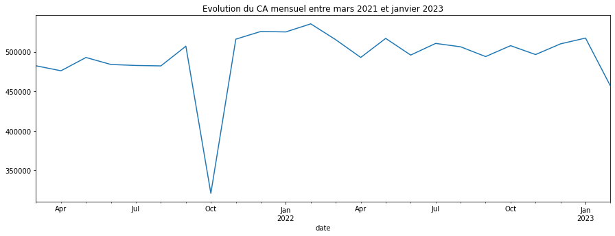

```
Chiffre d'affaires du 01/03/2021 au 28/02/2022 : 5831737
Chiffre d'affaires du 01/03/2022 au 28/02/2023 : 6021992
```

```python
# Affichage du chiffre d'affaires mensuel entre mars 2021 et février 2023
memo=df_ca['price'].resample('M').sum().plot()
memo=plt.title('Evolution du CA mensuel entre mars 2021 et janvier 2023')
memo=plt.show()
total1=df_ca.loc[df_ca.index < '2022-03-01']['price'].sum()
total2=df_ca.loc[df_ca.index > '2022-03-01']['price'].sum()
print("Chiffre d'affaires du 01/03/2021 au 28/02/2022 :",round(total1))
print("Chiffre d'affaires du 01/03/2022 au 28/02/2023 :",round(total2))
```

Une anomalie majeure apparait :chiffre d'affaires très bas sur le mois d'octobre 2021 (année N-1) : que s'est-il passé ?  
==> Analyse des transactions portant sur le mois d'octobre : visualisation des ventes par journée pour le mois d'octobre 2021

**==> Analyse problématique diminution du CA en octobre 2021**

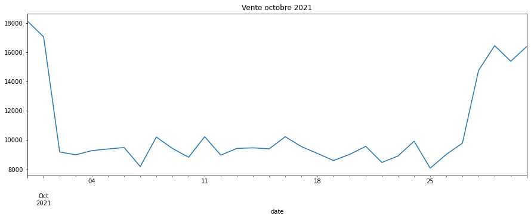

```python
#Focus sur les transactions d'octobre 2021
memo=df_ca.loc[(df_ca.index > '2021-09-30') & (df_ca.index < '2021-11-01')]['price'].resample('D').sum().plot()
memo=plt.title('Vente octobre 2021')
memo=plt.show()
```

Entre le 2 et le 27 octobre, le nombre de transactions a diminué ==> il faut analyser plus finement les ventes par catégorie

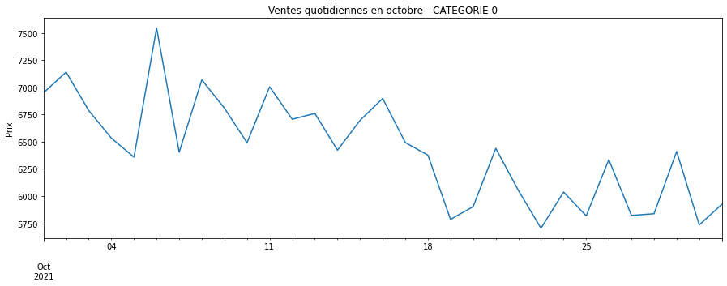

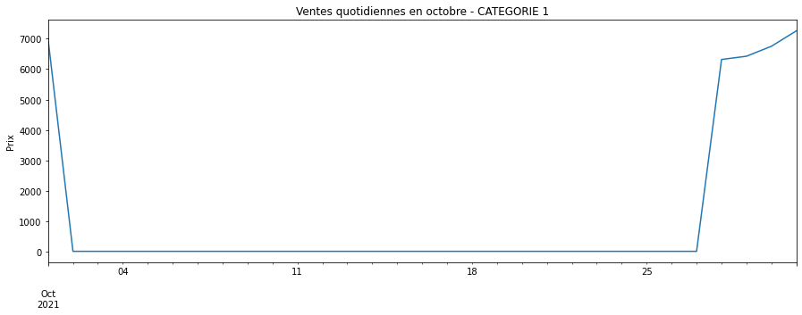

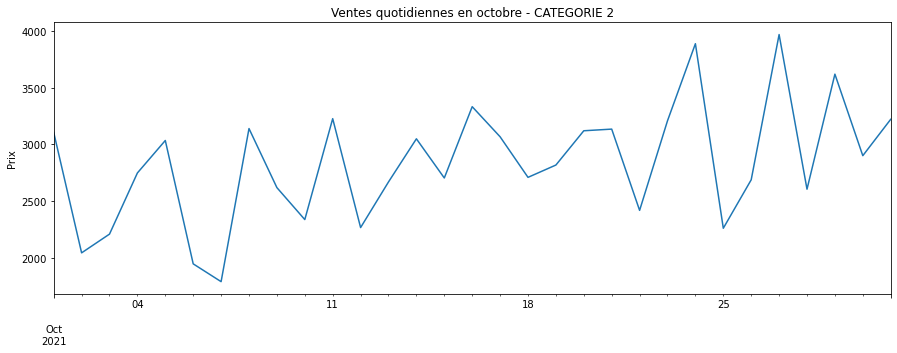

[output not shown]

```python
#Analyse des transactions portant sur le mois d'octobre
#Création d'un dataframe portant sur les transactions d'octobre
df_transaction_octobre=df_ca.loc[(df_ca.index > '2021-10-01') & (df_ca.index < '2021-11-01')]
df_transaction_octobre2=df_ca.loc[(df_ca.index > '2022-10-01') & (df_ca.index < '2023-11-01')]

#Affichage des courbes de ventes quotidiennes en octobre par catégorie

for i in [0, 1, 2]:
    memo=df_transaction_octobre.loc[df_transaction_octobre['categ']==i]['price'].resample('D').sum().plot()
    label="cat " + str(i)
    titre="Ventes quotidiennes en octobre - CATEGORIE " + str(i)
    memo=plt.title(titre)
    memo=plt.ylabel('Prix')
    memo=plt.xlabel(None)
    memo=plt.show()

print("Chiffres pour octobre période 2, catégorie 1:",len(df_transaction_octobre2.loc[df_transaction_octobre2['categ']==1]))
```

Entre le 2 et le 27 octobre, il n'y a pas de transactions pour la catégorie 1 :  
- pas de vente dans la catégorie 1 ?  
- lié à un problème technique de remontée de donnée ?  
- problème de produits qui ne sont plus en stock ?  
A voir avec les services informatique et marketing ultérieurement.

### **Comparaison des CA sur les 2 périodes de 12 mois :**

- entre mars 2021 et février 2022  
- entre mars 2022 et février 2023

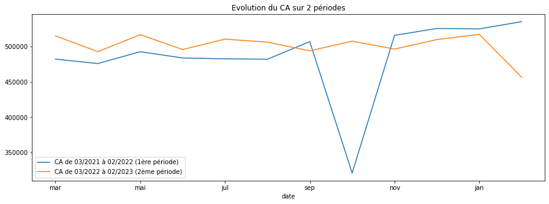

```python
# Graphique CA pour les 2 périodes
df1=df_ca.loc[df_ca.index < '2022-03-01']['price'].resample('M').sum().reset_index()
df2=df_ca.loc[df_ca.index > '2022-03-01']['price'].resample('M').sum().reset_index()
liste_mois=('mar','avr','mai','jun','jul','aou','sep','oct','nov','dec','jan','fev')
df1['date']=df2['date']=liste_mois
memo=ax=df1.plot(x='date', y='price',label='CA de 03/2021 à 02/2022 (1ère période)')
memo=df2.plot(ax=ax,x='date', y='price',label='CA de 03/2022 à 02/2023 (2ème période)')
memo=plt.title('Evolution du CA sur 2 périodes')
memo=plt.show
```

Après avoir superposé les 2 courbes, on compare les 2 périodes :  
==> de mars à août les 2 courbes de ventes sont parallèles avec des ventes meilleures sur la 2ème période  
==> à partir du mois de septembre, les ventes de la 2ème période ont diminué par rapport à celles de la 1ère période  
Il va être nécessaire d'analyser les ventes pour ces 2 périodes par catégorie

**==> Analyse chiffre d'affaires par catégorie pour les 2 périodes**

```
Nombre achats période 1:  169173
Nombre produits achetés période 1 :  337185
Nombre achats période 2:  173102
Nombre produits achetés période 2 :  341926

CA 1ère période catégorie 0 : 2230428.29
CA 2ème période catégorie 0 : 2189302.68
```

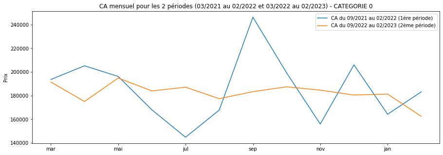

```
CA 1ère période catégorie 1 : 2247384.41
CA 2ème période catégorie 1 : 2406338.28
```

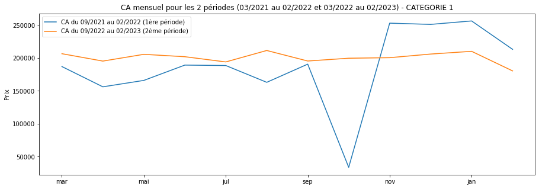

```
CA 1ère période catégorie 2 : 1353924.35
CA 2ème période catégorie 2 : 1426350.67
```

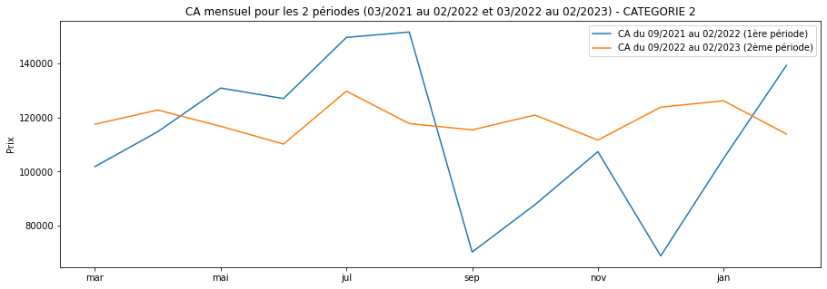

```python
#Création des dataframes par catégorie
df_prem_per=df_ca.loc[df_ca.index < '2022-03-01']
print("Nombre achats période 1: ",len(df_prem_per['session_id'].unique()))
print("Nombre produits achetés période 1 : ",len(df_prem_per))

df_deux_per=df_ca.loc[df_ca.index > '2022-03-01']
print("Nombre achats période 2: ",len(df_deux_per['session_id'].unique()))
print("Nombre produits achetés période 2 : ",len(df_deux_per))

liste_mois=('mar','avr','mai','jun','jul','aou','sep','oct','nov','dec','jan','fev')


#Affichage des courbes de ventes quotidiennes par catégorie pour ces 2 périodes

for i in [0,1,2]:
    df_temp1=df_prem_per.loc[df_prem_per['categ']==i]['price'].resample('M').sum().reset_index()
    print("\nCA 1ère période catégorie",i,":",round(df_temp1['price'].sum(),2))
    df_temp2=df_deux_per.loc[df_deux_per['categ']==i]['price'].resample('M').sum().reset_index()
    print("CA 2ème période catégorie",i,":",round(df_temp2['price'].sum(),2))
    df_temp1['date']=df_temp2['date']=liste_mois
    memo=ax=df_temp1.plot(x='date', y='price',label='CA du 09/2021 au 02/2022 (1ère période)')
    memo=df_temp2.plot(ax=ax,x='date', y='price',label='CA du 09/2022 au 02/2023 (2ème période)')
    titre="CA mensuel pour les 2 périodes (03/2021 au 02/2022 et 03/2022 au 02/2023) - CATEGORIE " + str(i)
    memo=plt.title(titre)
    memo=plt.ylabel('Prix')
    memo=plt.xlabel(None)
    memo=plt.show()
```

Après avoir superposé les 2 courbes, on compare les 2 périodes de septembre à octobre sur les 3 catégories :  
==> catégorie 0 : CA 2ème période < CA 1ère période. Pic observé en septembre (rentrée scolaire)  
==> catégorie 1 : CA 2ème période > CA 1ère période : non significatif car il manque les données d'octobre 2021  
Pic observé en fin d'année (fêtes de fin d'année)  
==> catégorie 2 : CA 2ème période > CA 1ère période. Pic observé pendant l'été et au mois de février (semestres universitaires)  
Pour la 2ème période et pour toutes les catégories, diminution globale du CA à partir du mois de janvier :  
* problème de stock ?  
* moins de connexions client ?  
Nombre achats période 2> Nombre d'achats période 1  
Nombre livres achetés période 2> Nombre livres achetés période 1  
Attention chiffres manquants octobre 2021  
Il serait intéressant d'analyser le nombre de connexions client sur le site et le nombre de connexions n'ayant pas abouti à un achat. Il faudrait également connaitre l'évolution des stocks (produits qui ne sont plus proposés en ligne à cause d'un non réapprovisionnement.

### **Tendance CA - Décomposition du CA en moyenne mobile**

Evolution trimestrielle du chiffre d'affaires.  
Cacul de la moyenne mobile d'ordre 3.

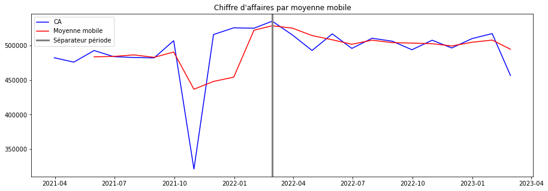

```python
df_ca_mensuel=df_ca['price'].resample('M').sum()
rolling_mean = df_ca_mensuel.rolling(window = 3).mean()

memo=plt.plot(df_ca_mensuel, color = 'blue', label = 'CA')
memo=plt.plot(rolling_mean, color = 'red', label = 'Moyenne mobile')
memo=plt.axvline(x=df_ca_mensuel.index[11],color='gray',linewidth=3, label="Séparateur période")
memo=plt.legend(loc = 'best')
memo=plt.title("Chiffre d'affaires par moyenne mobile")
memo=plt.show()
```

Observations tendances CA :  
- Hausse du CA entre mars 2021 et février 2022 avec un incident en octobre 2021  
- Baisse progressive du CA depuis mars 2022 avec une baisse plus nette en février 2023.  
Nécessité d'analyser d'autres données afin d'afiner l'analyse par catégorie

**==> Décomposition du chiffre d'affaires en moyenne mobile par catégorie**

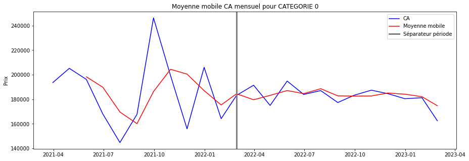

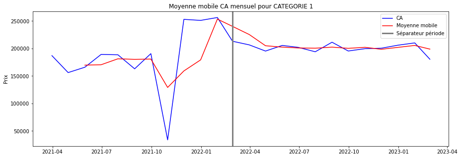

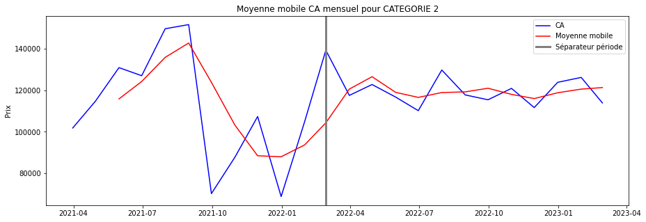

```python
#Analyse de la moyenne mobile du CA par catégorie
#Affichage des courbes de ventes par catégorie

for i in [0, 1, 2]:
    tempo=df_ca.loc[df_ca['categ']==i]['price'].resample('M').sum()
    rolling_mean = tempo.rolling(window = 3).mean()
    rolling_std = tempo.rolling(window = 3).std()
    memo=plt.plot(tempo, color = 'blue', label = 'CA')
    memo=plt.plot(rolling_mean, color = 'red', label = 'Moyenne mobile')
    memo=plt.axvline(x=tempo.index[11],color='gray',linewidth=3, label="Séparateur période")
    memo=plt.legend(loc = 'best')
    memo=plt.title('Moyenne et Ecart-type mobiles')
    label="cat " + str(i)
    titre="Moyenne mobile CA mensuel pour CATEGORIE " + str(i)
    memo=plt.title(titre)
    memo=plt.ylabel('Prix')
    memo=plt.xlabel(None)
    memo=plt.show()
```

### **Evolution du CA mensuel entre mars 2021 et février 2023 (boxplot)**

La visualisation en boxplot confirme ce que nous venons de voir de façon plus visible.

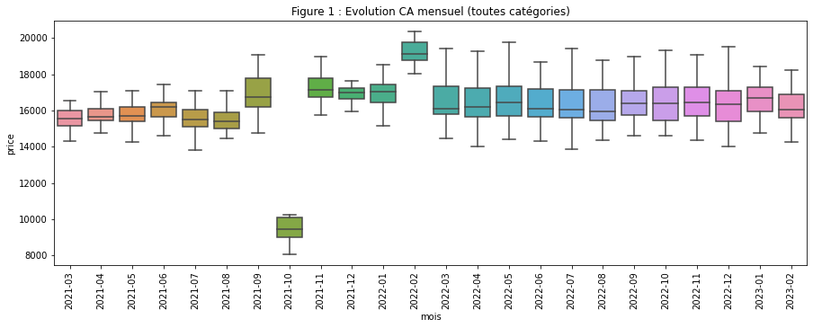

```python
dft=df_ca.copy()
dft=dft['price'].resample('D').sum().reset_index()
dft['mois']=dft['date'].dt.to_period ('M')


memo=sns.boxplot(x='mois', y='price', data=dft,showfliers=False)
memo=plt.xticks(rotation=90)
memo=plt.title("Figure 1 : Evolution CA mensuel (toutes catégories)")
plt.show()
```

On constate :  
- l'anomalie d'octobre 2021 dont on ne doit pas tenir compte  
- une augmentation des ventes pour le mois de février 2022  
Une analyse plus fine par catégorie doit être réalisée afin d'avoir une meilleure vision de la fluctuation des ventes.

**==> Analyse des ventes par catégorie**

```
                                             Evolution CA mensuel par catégorie
```

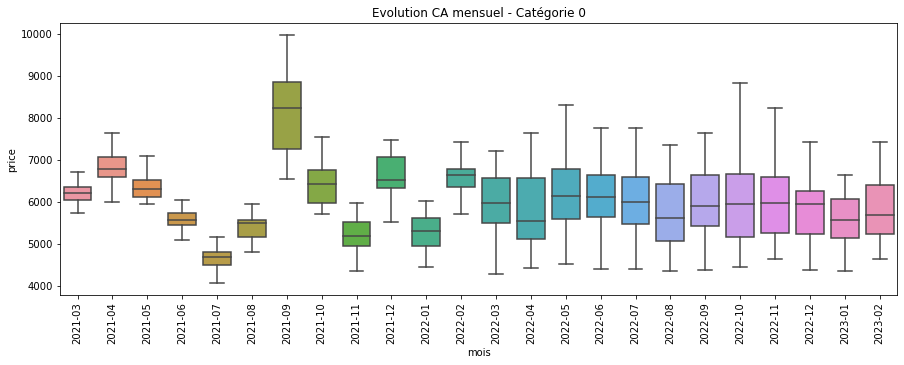

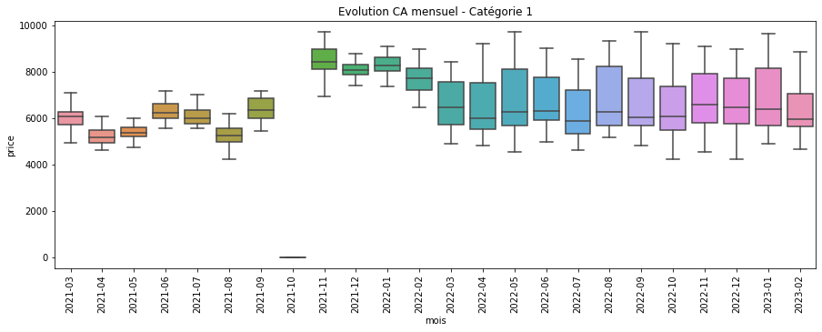

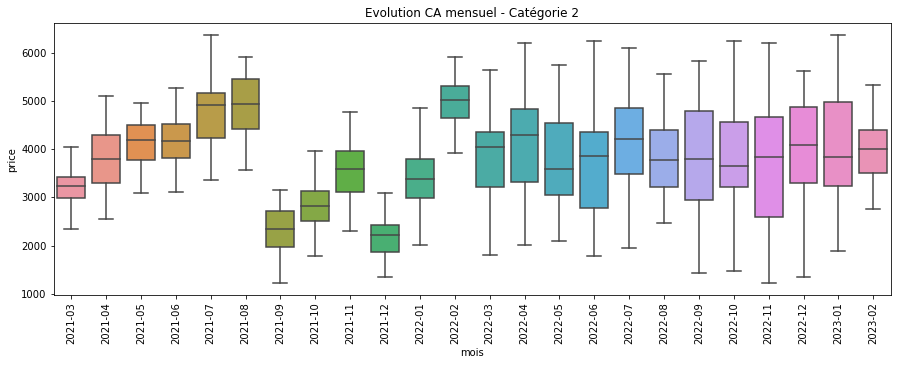

```python
dft0=df_ca.loc[df_ca['categ']==0].copy()
dft1=df_ca.loc[df_ca['categ']==1].copy()
dft2=df_ca.loc[df_ca['categ']==2].copy()

df_temp0=dft0['price'].resample('D').sum().reset_index()
df_temp0['mois']=df_temp0['date'].dt.to_period ('M')

df_temp1=dft1['price'].resample('D').sum().reset_index()
df_temp1['mois']=df_temp0['date'].dt.to_period ('M')

df_temp2=dft2['price'].resample('D').sum().reset_index()
df_temp2['mois']=df_temp0['date'].dt.to_period ('M')


text="Evolution CA mensuel par catégorie "
x=text.rjust(80)
print(black(x,'bold'))

memo=sns.boxplot(x='mois', y='price', data=df_temp0,showfliers=False)
memo=plt.xticks(rotation=90)
memo=plt.title('Evolution CA mensuel - Catégorie 0')
plt.show()
memo=sns.boxplot(x='mois', y='price', data=df_temp1,showfliers=False)
memo=plt.xticks(rotation=90)
memo=plt.title('Evolution CA mensuel - Catégorie 1')
plt.show()

memo=sns.boxplot(x='mois', y='price', data=df_temp2,showfliers=False)
memo=plt.xticks(rotation=90)
memo=plt.title('Evolution CA mensuel - Catégorie 2')
plt.show()
```

On constate :  
- durant la 1ère période il y a des fluctuations de ventes : attention il s'agit de la 1ère année d'existence du site (les fluctuations de stock peuvent expliquer les fluctuations de vente : si on vend tous les exemplaires d'un livre à un mois M, il risque de n'être plus disponible à la vente pour le mois M+1  
- durant la 2ème période : ventes beaucoup plus stables mais achats plus variés  
Afin de compléter l'analyse, il aurait été intéressant d'avoir une base de gestion des stocks et de croiser ces données avec celles du chiffre d'affaires.  
Globalement on constate plus de transactions pour les mois de septembre et de décembre (rentrée scolaire et fêtes de fin d'année) :  
Pour la catégorie 0 : plus de ventes en septembre (rentrée scolaire ?)  
Pour la catégorie 1 : plus de ventes en novembre, décembre et janvier (fêtes de fin d'année ?)  
Pour la catégorie 2 : plus de ventes en juillet, août et février (rentrée scolaire ? semestre universitaire ?)

Suite du projet : Analyses univariées